# Nasua nasua Variable Selection

Author

Florencia Grattarola

Published

October 1, 2024

Variable Selection for *Nasua nasua*, using the data generated in the previous step.

- R Libraries

```r
library(knitr)
library(dismo)
library(gbm)
library(randomForest)
library(ranger) # for the Random Forest
library(terra)
terraOptions(tempdir='big_data/temp')
library(sf)
library(tidyverse)
```

- `bio1`: Annual Mean Temperature, from Bioclimatic variables (WorldClim V2.1)
- `bio2`: Mean Diurnal Range (Mean of monthly (max temp - min temp)), from Bioclimatic variables (WorldClim V2.1)
- `bio3`: Isothermality (BIO2/BIO7) (×100), from Bioclimatic variables (WorldClim V2.1)
- `bio4`: Temperature Seasonality (standard deviation ×100), from Bioclimatic variables (WorldClim V2.1)
- `bio5`: Max Temperature of Warmest Month, from Bioclimatic variables (WorldClim V2.1)
- `bio6`: Min Temperature of Coldest Month, from Bioclimatic variables (WorldClim V2.1)
- `bio7`: Temperature Annual Range (BIO5-BIO6), from Bioclimatic variables (WorldClim V2.1)
- `bio8`: Mean Temperature of Wettest Quarter, from Bioclimatic variables (WorldClim V2.1)
- `bio9`: Mean Temperature of Driest Quarter, from Bioclimatic variables (WorldClim V2.1)
- `bio10`: Mean Temperature of Warmest Quarter, from Bioclimatic variables (WorldClim V2.1)
- `bio11`: Mean Temperature of Coldest Quarter, from Bioclimatic variables (WorldClim V2.1)
- `bio12`: Annual Precipitation, from Bioclimatic variables (WorldClim V2.1)
- `bio13`: Precipitation of Wettest Month, from Bioclimatic variables (WorldClim V2.1)
- `bio14`: Precipitation of Driest Month, from Bioclimatic variables (WorldClim V2.1)
- `bio15`: Precipitation Seasonality (Coefficient of Variation), from Bioclimatic variables (WorldClim V2.1)
- `bio16`: Precipitation of Wettest Quarter, from Bioclimatic variables (WorldClim V2.1)
- `bio17`: Precipitation of Driest Quarter, from Bioclimatic variables (WorldClim V2.1)
- `bio18`: Precipitation of Warmest Quarter, from Bioclimatic variables (WorldClim V2.1)
- `bio19`: Precipitation of Coldest Quarter, from Bioclimatic variables (WorldClim V2.1)
- `elev`: Elevation (WorldClim V2.1 SRTM elevation data), from Bioclimatic variables (WorldClim V2.1)
- `urban`: Urban and Built-up Lands, from Land cover LC1 (MODIS TERRA LandCover_Type_Yearly_500m (MCD12Q1))
- `barren`: Barren, from Land cover LC1 (MODIS TERRA LandCover_Type_Yearly_500m (MCD12Q1))
- `water`: Water Bodies, from Land cover LC1 (MODIS TERRA LandCover_Type_Yearly_500m (MCD12Q1))
- `savanna`: Savannas, from Land cover LC1 (MODIS TERRA LandCover_Type_Yearly_500m (MCD12Q1))
- `woodysavanna`: Woody savannas, from Land cover LC1 (MODIS TERRA LandCover_Type_Yearly_500m (MCD12Q1))
- `wetland`: Permanent Wetlands, from Land cover LC1 (MODIS TERRA LandCover_Type_Yearly_500m (MCD12Q1))
- `grass`: Grasslands, from Land cover LC1 (MODIS TERRA LandCover_Type_Yearly_500m (MCD12Q1))
- `npp`: Net Primary Production (NPP) (MODIS TERRA Net_PP_GapFil_Yearly_500m (M*D17A3HGF))
- `tree`: Percentage of Tree Cover, from Vegetation Continuous Fields (MODIS TERRA Veg_Cont_Fields_Yearly_250m (MOD44B))
- `nontree`: Percentage of No Tree Cover, from Vegetation Continuous Fields (MODIS TERRA Veg_Cont_Fields_Yearly_250m (MOD44B))
- `nonveg`: Percentage of Non Tree Vegetation Cover, from Vegetation Continuous Fields (MODIS TERRA Veg_Cont_Fields_Yearly_250m (MOD44B))

```r
bio <- rast('big_data/bio_high.tif')
elev <- rast('big_data/elev_high.tif')
urban <- rast('big_data/urban_high.tif') %>% resample(., elev)
barren  <- rast('big_data/barren_high.tif') %>% resample(., elev)
water <- rast('big_data/water_high.tif') %>% resample(., elev)
savanna <- rast('big_data/savanna_high.tif') %>% resample(., elev)
woodysavanna <- rast('big_data/woodysavanna_high.tif') %>% resample(., elev)
wetland <- rast('big_data/wetland_high.tif') %>% resample(., elev)
grass <- rast('big_data/grass_high.tif') %>% resample(., elev)
npp <- rast('big_data/npp_high.tif') %>% resample(., elev)
names(npp) <- 'npp'
tree <- rast('big_data/tree_high.tif') %>% resample(., elev)
nontree <- rast('big_data/nontree_high.tif') %>% resample(., elev)
nonveg <- rast('big_data/nonveg_high.tif') %>% resample(., elev)

env <- c(bio, elev, urban, barren, water,
         savanna, woodysavanna, wetland,
         grass, npp, tree, nontree, nonveg) %>% scale()

rm(bio, elev, urban, barren, water,
         savanna, woodysavanna, wetland,
         grass, npp, tree, nontree, nonveg)

gc()
```

## Nasua nasua’ preferences

We will use the data from both periods

```r
PA_time1 <- readRDS('data/species_POPA_data/PA_nnasua_time1_blobs.rds')%>% ungroup()
PA_time2 <- readRDS('data/species_POPA_data/PA_nnasua_time2_blobs.rds')%>% ungroup()

PA_time1 %>% st_drop_geometry() %>% head() %>% kable()
```

| ID | presence | temporalSpan | effort | blobArea |
| --- | --- | --- | --- | --- |
| 1 | 1 | 5589 days | 93771 | 2761279588 [m^2] |
| 2 | 0 | 270 days | 381 | 160668368 [m^2] |
| 3 | 0 | 527 days | 507 | 13742467 [m^2] |
| 4 | 0 | 31 days | 676 | 3581363 [m^2] |
| 5 | 1 | 2208 days | 51168 | 435868381 [m^2] |
| 6 | 0 | 0 days | 360 | 65695043 [m^2] |

```r
PA_time2 %>% st_drop_geometry() %>% head() %>% kable()
```

| ID | presence | temporalSpan | effort | blobArea |
| --- | --- | --- | --- | --- |
| 1 | 0 | 92 days | 95 | 3998173 [m^2] |
| 2 | 1 | 92 days | 92 | 3998173 [m^2] |
| 3 | 0 | 276 days | 269 | 10776792 [m^2] |
| 4 | 0 | 92 days | 95 | 3998173 [m^2] |
| 5 | 1 | 92 days | 3231 | 147932384 [m^2] |
| 6 | 1 | 184 days | 177 | 6948021 [m^2] |

Presence-absence data for the second period

### Preparation of data for the tests

```r
# combine pre and pos datasets
PA.data <- st_join(PA_time1, PA_time2 %>% dplyr::select(presence), left = T) %>%
  group_by(ID) %>%
  mutate(presence=max(presence.x, presence.y, na.rm = T))

# calculate area, coordinates, and extract env predictors for each blob
PA.coords <- st_coordinates(st_centroid(PA.data)) %>% as_tibble()
PA.area <- as.numeric(PA.data$blobArea)

PA.env <- terra::extract(x = env, y = vect(PA.data),
                         fun = mean, rm.na=T) %>%
  mutate(across(where(is.numeric), ~ifelse(is.nan(.), NA, .)))

## the data
PA <- data.frame(PA.coords,
                 area = PA.area,
                 presabs = PA.data$presence,
                 env = PA.env)
```

### Correlation between variables

```r
PA %>% filter(!if_any(everything(), is.na)) %>% dplyr::select(-c(1:5)) %>% cor() %>% kable()
```

|  | env.bio_1 | env.bio_2 | env.bio_3 | env.bio_4 | env.bio_5 | env.bio_6 | env.bio_7 | env.bio_8 | env.bio_9 | env.bio_10 | env.bio_11 | env.bio_12 | env.bio_13 | env.bio_14 | env.bio_15 | env.bio_16 | env.bio_17 | env.bio_18 | env.bio_19 | env.elev | env.urban | env.barren | env.water | env.savanna | env.woodysavanna | env.wetland | env.grass | env.npp | env.tree | … |
| --- | --- | --- | --- | --- | --- | --- | --- | --- | --- | --- | --- | --- | --- | --- | --- | --- | --- | --- | --- | --- | --- | --- | --- | --- | --- | --- | --- | --- | --- | --- |
| env.bio_1 | 1.0000000 | 0.9277685 | 0.9680772 | 0.2307470 | 0.3634981 | -0.0951485 | 0.2746619 | 0.4118926 | -0.1070184 | -0.2463900 | 0.2045213 | -0.2089985 | 0.6945268 | -0.6845689 | 0.8431389 | 0.9127796 | -0.5574188 | 0.8656259 | 0.9064203 | -0.6672470 | -0.2199917 | -0.0988993 | 0.2970331 | 0.0157981 | -0.0178632 | 0.1717186 | -0.0952232 | -0.5597867 | 0.2240506 | … |
| env.bio_2 | 0.9277685 | 1.0000000 | 0.8165906 | 0.1075245 | 0.1188005 | -0.0142668 | 0.1113807 | 0.1634706 | -0.0229253 | -0.3061136 | 0.1963059 | -0.1434531 | 0.4374044 | -0.3765883 | 0.9281506 | 0.7803705 | -0.3280903 | 0.8630663 | 0.7864866 | -0.8299466 | -0.2426688 | -0.1149203 | 0.2763437 | 0.0455453 | 0.0059932 | 0.2431852 | -0.1858529 | -0.6187896 | 0.2406395 | … |
| env.bio_3 | 0.9680772 | 0.8165906 | 1.0000000 | 0.3259163 | 0.4848414 | -0.0862766 | 0.3152193 | 0.5419459 | -0.0982183 | -0.2458973 | 0.2525386 | -0.2802071 | 0.8211485 | -0.8416269 | 0.7325133 | 0.9543484 | -0.6895251 | 0.7810742 | 0.9355039 | -0.5441296 | -0.1766341 | -0.0771973 | 0.3212806 | -0.0055106 | -0.0356177 | 0.0992988 | -0.0863876 | -0.4406327 | 0.2522378 | … |
| env.bio_4 | 0.2307470 | 0.1075245 | 0.3259163 | 1.0000000 | 0.7697691 | 0.7195441 | -0.4505835 | 0.7897426 | 0.7175210 | 0.3221163 | 0.7402330 | -0.5344230 | 0.5338214 | -0.4328267 | -0.0489799 | 0.4499365 | -0.6074777 | 0.0880539 | 0.3581213 | -0.2316853 | 0.0159292 | -0.1427406 | 0.3069321 | -0.4263131 | -0.1084147 | -0.1130280 | -0.1652261 | 0.2228391 | 0.5550972 | … |
| env.bio_5 | 0.3634981 | 0.1188005 | 0.4848414 | 0.7697691 | 1.0000000 | 0.1873097 | 0.1478717 | 0.9786573 | 0.1769194 | 0.3501940 | 0.4335205 | -0.3416387 | 0.6839703 | -0.6703316 | 0.0004906 | 0.4999338 | -0.6356556 | 0.2278849 | 0.4294807 | -0.0316409 | 0.0445628 | -0.1593074 | 0.2457074 | -0.3591374 | -0.0754648 | -0.1285543 | 0.1192867 | 0.0732885 | 0.3146959 | … |
| env.bio_6 | -0.0951485 | -0.0142668 | -0.0862766 | 0.7195441 | 0.1873097 | 1.0000000 | -0.8746471 | 0.1881482 | 0.9964870 | 0.1761052 | 0.7688182 | -0.5222235 | 0.1060483 | 0.1135350 | -0.1837474 | 0.1253199 | -0.2910181 | -0.1386426 | 0.0230732 | -0.2932452 | -0.0364798 | -0.0480476 | 0.2863280 | -0.3565638 | -0.0936928 | -0.0002935 | -0.3410927 | 0.2860967 | 0.5876459 | … |
| env.bio_7 | 0.2746619 | 0.1113807 | 0.3152193 | -0.4505835 | 0.1478717 | -0.8746471 | 1.0000000 | 0.1455048 | -0.8872850 | -0.1179562 | -0.5677000 | 0.3637339 | 0.2293253 | -0.3953841 | 0.2278896 | 0.1230539 | 0.0066533 | 0.2619221 | 0.1867343 | 0.2580057 | 0.0373240 | -0.0025900 | -0.1561542 | 0.2429381 | 0.0735001 | -0.0444759 | 0.3032344 | -0.2380475 | -0.4243439 | … |
| env.bio_8 | 0.4118926 | 0.1634706 | 0.5419459 | 0.7897426 | 0.9786573 | 0.1881482 | 0.1455048 | 1.0000000 | 0.1783178 | 0.3072965 | 0.4548494 | -0.4161515 | 0.7139923 | -0.7222646 | 0.0371262 | 0.5697294 | -0.6982123 | 0.2514146 | 0.4978131 | -0.0735110 | 0.0636457 | -0.1553539 | 0.2695250 | -0.3166474 | -0.0585876 | -0.1564683 | 0.0376607 | 0.0834781 | 0.3369544 | … |
| env.bio_9 | -0.1070184 | -0.0229253 | -0.0982183 | 0.7175210 | 0.1769194 | 0.9964870 | -0.8872850 | 0.1783178 | 1.0000000 | 0.1760919 | 0.7694968 | -0.5173054 | 0.0944417 | 0.1243957 | -0.1905535 | 0.1136467 | -0.2810418 | -0.1510809 | 0.0117426 | -0.2924391 | -0.0366887 | -0.0505332 | 0.2804922 | -0.3593879 | -0.0946451 | -0.0003621 | -0.3486109 | 0.2977312 | 0.5871058 | … |
| env.bio_10 | -0.2463900 | -0.3061136 | -0.2458973 | 0.3221163 | 0.3501940 | 0.1761052 | -0.1179562 | 0.3072965 | 0.1760919 | 1.0000000 | -0.1256464 | -0.0827932 | -0.0937538 | 0.1139535 | -0.4535522 | -0.2379504 | -0.0220895 | -0.0386619 | -0.3600452 | 0.2518724 | 0.2617832 | -0.1299675 | -0.1532953 | -0.2420074 | -0.0106526 | -0.0554615 | 0.0994479 | 0.2626821 | -0.0447537 | … |
| env.bio_11 | 0.2045213 | 0.1963059 | 0.2525386 | 0.7402330 | 0.4335205 | 0.7688182 | -0.5677000 | 0.4548494 | 0.7694968 | -0.1256464 | 1.0000000 | -0.6408949 | 0.4522777 | -0.2363703 | 0.0194468 | 0.4631666 | -0.5753058 | 0.0249800 | 0.3802550 | -0.3926181 | -0.0959995 | -0.0360959 | 0.4112421 | -0.3482173 | -0.0579890 | -0.0341574 | -0.2920978 | 0.1263147 | 0.6163044 | … |
| env.bio_12 | -0.2089985 | -0.1434531 | -0.2802071 | -0.5344230 | -0.3416387 | -0.5222235 | 0.3637339 | -0.4161515 | -0.5173054 | -0.0827932 | -0.6408949 | 1.0000000 | -0.3687343 | 0.3259618 | 0.1702596 | -0.5332588 | 0.8003318 | -0.0745264 | -0.3635566 | 0.3196728 | -0.0849807 | 0.0204207 | -0.4559694 | 0.3405011 | 0.0051159 | -0.0858233 | 0.3819510 | -0.1825077 | -0.6015148 | … |
| env.bio_13 | 0.6945268 | 0.4374044 | 0.8211485 | 0.5338214 | 0.6839703 | 0.1060483 | 0.2293253 | 0.7139923 | 0.0944417 | -0.0937538 | 0.4522777 | -0.3687343 | 1.0000000 | -0.9127157 | 0.3237383 | 0.8344648 | -0.8297503 | 0.4765709 | 0.7668214 | -0.2104476 | -0.1099554 | -0.0015494 | 0.3433190 | -0.1472673 | -0.0848086 | -0.0657356 | -0.0084892 | -0.1492964 | 0.2964585 | … |
| env.bio_14 | -0.6845689 | -0.3765883 | -0.8416269 | -0.4328267 | -0.6703316 | 0.1135350 | -0.3953841 | -0.7222646 | 0.1243957 | 0.1139535 | -0.2363703 | 0.3259618 | -0.9127157 | 1.0000000 | -0.3081329 | -0.8064516 | 0.8052880 | -0.4432812 | -0.7677597 | 0.1058742 | 0.0473841 | 0.0148215 | -0.2620952 | 0.0616427 | 0.0564150 | 0.0741740 | -0.0230030 | 0.1162072 | -0.1952645 | … |
| env.bio_15 | 0.8431389 | 0.9281506 | 0.7325133 | -0.0489799 | 0.0004906 | -0.1837474 | 0.2278896 | 0.0371262 | -0.1905535 | -0.4535522 | 0.0194468 | 0.1702596 | 0.3237383 | -0.3081329 | 1.0000000 | 0.6208725 | -0.0737256 | 0.7699132 | 0.7046433 | -0.7249237 | -0.2729520 | -0.1012924 | 0.1337540 | 0.1749436 | 0.0061381 | 0.1864473 | -0.0801856 | -0.6339015 | 0.0609958 | … |
| env.bio_16 | 0.9127796 | 0.7803705 | 0.9543484 | 0.4499365 | 0.4999338 | 0.1253199 | 0.1230539 | 0.5697294 | 0.1136467 | -0.2379504 | 0.4631666 | -0.5332588 | 0.8344648 | -0.8064516 | 0.6208725 | 1.0000000 | -0.8275524 | 0.7031109 | 0.9372507 | -0.6145115 | -0.1500558 | -0.0641372 | 0.4249134 | -0.1007138 | -0.0388713 | 0.1214282 | -0.2129549 | -0.3433415 | 0.4187299 | … |
| env.bio_17 | -0.5574188 | -0.3280903 | -0.6895251 | -0.6074777 | -0.6356556 | -0.2910181 | 0.0066533 | -0.6982123 | -0.2810418 | -0.0220895 | -0.5753058 | 0.8003318 | -0.8297503 | 0.8052880 | -0.0737256 | -0.8275524 | 1.0000000 | -0.3431217 | -0.6877325 | 0.2626257 | -0.0045728 | 0.0090549 | -0.4447811 | 0.2534100 | 0.0538471 | -0.0209570 | 0.2134936 | -0.0171675 | -0.4890194 | … |
| env.bio_18 | 0.8656259 | 0.8630663 | 0.7810742 | 0.0880539 | 0.2278849 | -0.1386426 | 0.2619221 | 0.2514146 | -0.1510809 | -0.0386619 | 0.0249800 | -0.0745264 | 0.4765709 | -0.4432812 | 0.7699132 | 0.7031109 | -0.3431217 | 1.0000000 | 0.6030993 | -0.5932420 | -0.1325791 | -0.0854560 | 0.1957556 | -0.0224175 | 0.0303643 | 0.2194431 | -0.0799501 | -0.5467745 | 0.1622566 | … |
| env.bio_19 | 0.9064203 | 0.7864866 | 0.9355039 | 0.3581213 | 0.4294807 | 0.0230732 | 0.1867343 | 0.4978131 | 0.0117426 | -0.3600452 | 0.3802550 | -0.3635566 | 0.7668214 | -0.7677597 | 0.7046433 | 0.9372507 | -0.6877325 | 0.6030993 | 1.0000000 | -0.6138045 | -0.2184383 | -0.0579593 | 0.3513282 | 0.0298117 | -0.0538343 | 0.0817392 | -0.1339679 | -0.4222120 | 0.2793405 | … |
| env.elev | -0.6672470 | -0.8299466 | -0.5441296 | -0.2316853 | -0.0316409 | -0.2932452 | 0.2580057 | -0.0735110 | -0.2924391 | 0.2518724 | -0.3926181 | 0.3196728 | -0.2104476 | 0.1058742 | -0.7249237 | -0.6145115 | 0.2626257 | -0.5932420 | -0.6138045 | 1.0000000 | 0.1939057 | 0.1056507 | -0.2768266 | 0.0679176 | 0.0033027 | -0.2224196 | 0.3587738 | 0.3987217 | -0.3934171 | … |
| env.urban | -0.2199917 | -0.2426688 | -0.1766341 | 0.0159292 | 0.0445628 | -0.0364798 | 0.0373240 | 0.0636457 | -0.0366887 | 0.2617832 | -0.0959995 | -0.0849807 | -0.1099554 | 0.0473841 | -0.2729520 | -0.1500558 | -0.0045728 | -0.1325791 | -0.2184383 | 0.1939057 | 1.0000000 | -0.0113513 | -0.0629070 | -0.0503602 | 0.0548994 | -0.0616338 | -0.0789070 | 0.1355983 | -0.0391381 | … |
| env.barren | -0.0988993 | -0.1149203 | -0.0771973 | -0.1427406 | -0.1593074 | -0.0480476 | -0.0025900 | -0.1553539 | -0.0505332 | -0.1299675 | -0.0360959 | 0.0204207 | -0.0015494 | 0.0148215 | -0.1012924 | -0.0641372 | 0.0090549 | -0.0854560 | -0.0579593 | 0.1056507 | -0.0113513 | 1.0000000 | -0.0121373 | -0.0370293 | -0.0153823 | -0.0118264 | -0.0243199 | -0.0791489 | -0.0552519 | … |
| env.water | 0.2970331 | 0.2763437 | 0.3212806 | 0.3069321 | 0.2457074 | 0.2863280 | -0.1561542 | 0.2695250 | 0.2804922 | -0.1532953 | 0.4112421 | -0.4559694 | 0.3433190 | -0.2620952 | 0.1337540 | 0.4249134 | -0.4447811 | 0.1957556 | 0.3513282 | -0.2768266 | -0.0629070 | -0.0121373 | 1.0000000 | -0.1945147 | -0.0935378 | 0.1394400 | -0.1367836 | -0.3666331 | 0.7312940 | … |
| env.savanna | 0.0157981 | 0.0455453 | -0.0055106 | -0.4263131 | -0.3591374 | -0.3565638 | 0.2429381 | -0.3166474 | -0.3593879 | -0.2420074 | -0.3482173 | 0.3405011 | -0.1472673 | 0.0616427 | 0.1749436 | -0.1007138 | 0.2534100 | -0.0224175 | 0.0298117 | 0.0679176 | -0.0503602 | -0.0370293 | -0.1945147 | 1.0000000 | -0.0895060 | -0.1647097 | -0.1329225 | -0.1422405 | -0.4728660 | … |
| env.woodysavanna | -0.0178632 | 0.0059932 | -0.0356177 | -0.1084147 | -0.0754648 | -0.0936928 | 0.0735001 | -0.0585876 | -0.0946451 | -0.0106526 | -0.0579890 | 0.0051159 | -0.0848086 | 0.0564150 | 0.0061381 | -0.0388713 | 0.0538471 | 0.0303643 | -0.0538343 | 0.0033027 | 0.0548994 | -0.0153823 | -0.0935378 | -0.0895060 | 1.0000000 | -0.0826217 | -0.0950113 | -0.0010226 | -0.0703156 | … |
| env.wetland | 0.1717186 | 0.2431852 | 0.0992988 | -0.1130280 | -0.1285543 | -0.0002935 | -0.0444759 | -0.1564683 | -0.0003621 | -0.0554615 | -0.0341574 | -0.0858233 | -0.0657356 | 0.0741740 | 0.1864473 | 0.1214282 | -0.0209570 | 0.2194431 | 0.0817392 | -0.2224196 | -0.0616338 | -0.0118264 | 0.1394400 | -0.1647097 | -0.0826217 | 1.0000000 | -0.1324671 | -0.3579071 | 0.2280567 | … |
| env.grass | -0.0952232 | -0.1858529 | -0.0863876 | -0.1652261 | 0.1192867 | -0.3410927 | 0.3032344 | 0.0376607 | -0.3486109 | 0.0994479 | -0.2920978 | 0.3819510 | -0.0084892 | -0.0230030 | -0.0801856 | -0.2129549 | 0.2134936 | -0.0799501 | -0.1339679 | 0.3587738 | -0.0789070 | -0.0243199 | -0.1367836 | -0.1329225 | -0.0950113 | -0.1324671 | 1.0000000 | -0.1315989 | -0.4713395 | … |
| env.npp | -0.5597867 | -0.6187896 | -0.4406327 | 0.2228391 | 0.0732885 | 0.2860967 | -0.2380475 | 0.0834781 | 0.2977312 | 0.2626821 | 0.1263147 | -0.1825077 | -0.1492964 | 0.1162072 | -0.6339015 | -0.3433415 | -0.0171675 | -0.5467745 | -0.4222120 | 0.3987217 | 0.1355983 | -0.0791489 | -0.3666331 | -0.1422405 | -0.0010226 | -0.3579071 | -0.1315989 | 1.0000000 | -0.0514793 | … |
| env.tree | 0.2240506 | 0.2406395 | 0.2522378 | 0.5550972 | 0.3146959 | 0.5876459 | -0.4243439 | 0.3369544 | 0.5871058 | -0.0447537 | 0.6163044 | -0.6015148 | 0.2964585 | -0.1952645 | 0.0609958 | 0.4187299 | -0.4890194 | 0.1622566 | 0.2793405 | -0.3934171 | -0.0391381 | -0.0552519 | 0.7312940 | -0.4728660 | -0.0703156 | 0.2280567 | -0.4713395 | -0.0514793 | 1.0000000 | … |
| env.nontree | 0.2062536 | 0.2166631 | 0.1850997 | -0.0621585 | 0.0111147 | -0.0182868 | 0.0426928 | -0.0021094 | -0.0262272 | -0.1895589 | 0.0485094 | -0.0864016 | 0.1473409 | -0.0869051 | 0.1713212 | 0.1926602 | -0.1224094 | 0.1452967 | 0.2046471 | -0.1110525 | -0.0759533 | -0.0807519 | 0.7510133 | 0.1121871 | -0.1242026 | 0.2518196 | 0.2060164 | -0.5282644 | 0.2829091 | … |
| env.nonveg | 0.3363748 | 0.3296479 | 0.3456002 | 0.2637806 | 0.2166840 | 0.2489975 | -0.1363232 | 0.2275318 | 0.2427548 | -0.1940213 | 0.3631482 | -0.3824726 | 0.3316464 | -0.2510543 | 0.2109901 | 0.4277087 | -0.3930256 | 0.2479591 | 0.3658683 | -0.3183675 | -0.0996535 | 0.0969951 | 0.9155486 | -0.2116674 | -0.0928695 | 0.2815450 | -0.1088121 | -0.4655389 | 0.7448210 | … |

## Variable Importance analyses

### Simple GLM

```r
presabs.glm <- PA %>%
  dplyr::select(-c(1,2,3,5)) %>%
  filter(!is.na(env.elev)&!is.na(env.bio_1))

glm.full<- glm(presabs ~.,
               family = "binomial",
               data = presabs.glm)

summary(glm.full)
```

```
Call:
glm(formula = presabs ~ ., family = "binomial", data = presabs.glm)

Deviance Residuals:
    Min       1Q   Median       3Q      Max
-2.9411  -0.7118  -0.2832   0.8501   2.7646

Coefficients:
                   Estimate Std. Error z value Pr(>|z|)
(Intercept)      -1.220e+02  1.268e+02  -0.962 0.336191
env.bio_1         2.068e+01  7.414e+00   2.790 0.005278 **
env.bio_2         2.001e+01  8.120e+00   2.465 0.013713 *
env.bio_3        -4.800e+01  1.577e+01  -3.043 0.002339 **
env.bio_4        -6.146e-01  1.880e+00  -0.327 0.743698
env.bio_5        -4.680e+00  1.519e+00  -3.081 0.002064 **
env.bio_6        -1.877e+00  1.527e+00  -1.230 0.218850
env.bio_7         6.954e-01  5.638e-01   1.233 0.217399
env.bio_8         5.318e+00  2.119e+00   2.510 0.012080 *
env.bio_9         3.470e+00  2.011e+00   1.725 0.084451 .
env.bio_10       -8.813e-01  4.301e-01  -2.049 0.040455 *
env.bio_11       -1.889e-02  5.247e-01  -0.036 0.971286
env.bio_12        6.526e+00  1.963e+00   3.324 0.000887 ***
env.bio_13       -3.026e+00  1.358e+00  -2.229 0.025816 *
env.bio_14       -2.300e+01  8.595e+00  -2.677 0.007437 **
env.bio_15        1.619e+05  9.427e+05   0.172 0.863623
env.bio_16       -2.714e+05  1.580e+06  -0.172 0.863618
env.bio_17       -2.307e+05  1.343e+06  -0.172 0.863613
env.bio_18        2.675e-01  9.097e-01   0.294 0.768753
env.bio_19       -1.730e+00  1.368e+00  -1.265 0.205919
env.elev         -1.383e+00  9.514e-01  -1.454 0.146024
env.urban         8.859e-01  3.034e-01   2.919 0.003506 **
env.barren       -6.111e+02  6.400e+02  -0.955 0.339672
env.water        -4.209e-01  2.489e-01  -1.691 0.090901 .
env.savanna       4.336e-01  2.248e-01   1.928 0.053795 .
env.woodysavanna  1.082e-01  2.400e-01   0.451 0.651936
env.wetland      -2.363e-01  1.399e-01  -1.689 0.091182 .
env.grass         1.459e-01  3.068e-01   0.475 0.634437
env.npp           3.387e-02  2.974e-01   0.114 0.909338
env.tree          6.086e-01  5.136e-01   1.185 0.236028
env.nontree      -7.827e-01  4.629e-01  -1.691 0.090836 .
env.nonveg        6.077e-01  5.866e-01   1.036 0.300211
---
Signif. codes:  0 '***' 0.001 '**' 0.01 '*' 0.05 '.' 0.1 ' ' 1

(Dispersion parameter for binomial family taken to be 1)

    Null deviance: 737.83  on 538  degrees of freedom
Residual deviance: 530.80  on 507  degrees of freedom
AIC: 594.8

Number of Fisher Scoring iterations: 14
```

```r
step(glm.full) # step might not work with gam so glm
```

```
Start:  AIC=594.8
presabs ~ env.bio_1 + env.bio_2 + env.bio_3 + env.bio_4 + env.bio_5 +
    env.bio_6 + env.bio_7 + env.bio_8 + env.bio_9 + env.bio_10 +
    env.bio_11 + env.bio_12 + env.bio_13 + env.bio_14 + env.bio_15 +
    env.bio_16 + env.bio_17 + env.bio_18 + env.bio_19 + env.elev +
    env.urban + env.barren + env.water + env.savanna + env.woodysavanna +
    env.wetland + env.grass + env.npp + env.tree + env.nontree +
    env.nonveg

                   Df Deviance    AIC
- env.bio_11        1   530.80 592.80
- env.npp           1   530.82 592.82
- env.bio_15        1   530.83 592.83
- env.bio_16        1   530.83 592.83
- env.bio_17        1   530.83 592.83
- env.bio_18        1   530.89 592.89
- env.bio_4         1   530.91 592.91
- env.woodysavanna  1   531.01 593.01
- env.grass         1   531.03 593.03
- env.nonveg        1   531.88 593.88
- env.tree          1   532.23 594.23
- env.bio_6         1   532.34 594.34
- env.bio_7         1   532.35 594.35
- env.bio_19        1   532.61 594.61
<none>                  530.80 594.80
- env.elev          1   532.89 594.89
- env.nontree       1   533.68 595.68
- env.bio_9         1   533.87 595.87
- env.water         1   533.98 595.98
- env.barren        1   534.47 596.47
- env.wetland       1   534.55 596.55
- env.savanna       1   534.60 596.60
- env.bio_10        1   535.19 597.19
- env.bio_13        1   536.24 598.24
- env.bio_8         1   537.24 599.24
- env.bio_2         1   537.32 599.32
- env.bio_14        1   538.48 600.48
- env.bio_1         1   538.91 600.91
- env.bio_3         1   540.65 602.65
- env.bio_5         1   540.74 602.74
```

[output cut: 378 more lines]

```
- env.bio_1    1   542.29 582.29
- env.bio_10   1   542.44 582.44
- env.bio_9    1   544.31 584.31
- env.bio_5    1   546.10 586.10
- env.bio_8    1   546.59 586.59
- env.bio_13   1   547.31 587.31
- env.barren   1   548.64 588.64
- env.bio_14   1   548.69 588.69
- env.urban    1   548.71 588.71
- env.bio_3    1   549.78 589.78
- env.nonveg   1   551.15 591.15
- env.bio_2    1   555.03 595.03
- env.bio_12   1   556.13 596.13
- env.nontree  1   562.25 602.25
- env.bio_17   1   569.29 609.29
```

```
Call:  glm(formula = presabs ~ env.bio_1 + env.bio_2 + env.bio_3 + env.bio_5 +
    env.bio_8 + env.bio_9 + env.bio_10 + env.bio_12 + env.bio_13 +
    env.bio_14 + env.bio_16 + env.bio_17 + env.bio_19 + env.urban +
    env.barren + env.water + env.savanna + env.wetland + env.nontree +
    env.nonveg, family = "binomial", data = presabs.glm)

Coefficients:
(Intercept)    env.bio_1    env.bio_2    env.bio_3    env.bio_5    env.bio_8
  -122.0334      14.0910      28.1436     -49.7123      -3.7771       4.2779
  env.bio_9   env.bio_10   env.bio_12   env.bio_13   env.bio_14   env.bio_16
     0.6677      -0.7139       7.0507      -3.1310     -25.8005     -10.7271
 env.bio_17   env.bio_19    env.urban   env.barren    env.water  env.savanna
   -18.5109      -1.4214       0.7897    -614.0368      -0.3299       0.3177
env.wetland  env.nontree   env.nonveg
    -0.2031      -1.1967       1.1297

Degrees of Freedom: 538 Total (i.e. Null);  518 Residual
Null Deviance:      737.8
Residual Deviance: 537.3    AIC: 579.3
```

### Boosted regression trees

Boosted regression trees were fitted using packages: `gbm` and `dismo` — specifically the `gbm.step()` function (Hijmans et al., 2017)

```
 GBM STEP - version 2.9

Performing cross-validation optimisation of a boosted regression tree model
for NA and using a family of bernoulli
Using 545 observations and 31 predictors
creating 10 initial models of 50 trees

 folds are stratified by prevalence
total mean deviance =  1.3663
tolerance is fixed at  0.0014
ntrees resid. dev.
50    1.2713
now adding trees...
100   1.2111
150   1.1706
```

[output cut: 44 more lines]

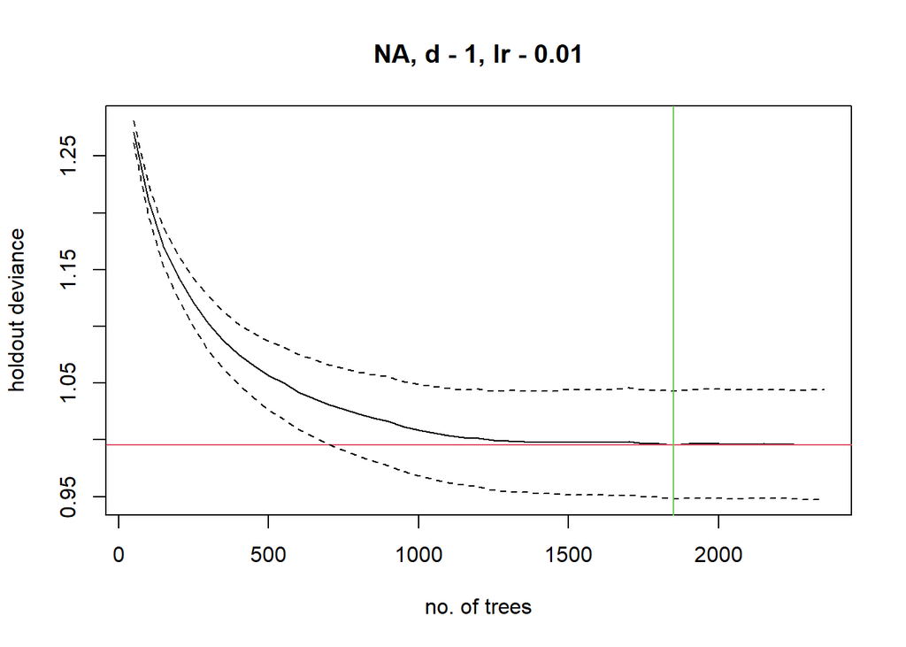

```
mean total deviance = 1.366
mean residual deviance = 0.764

estimated cv deviance = 0.995 ; se = 0.047

training data correlation = 0.731
cv correlation =  0.569 ; se = 0.038

training data AUC score = 0.922
cv AUC score = 0.826 ; se = 0.022

elapsed time -  0.11 minutes
```

```r
# cross-validation optimisation of a boosted regression tree model
brt <- gbm.step(data = PA,
                 gbm.x = 6:ncol(PA),
                 gbm.y = "presabs",
                 family = "bernoulli")
```

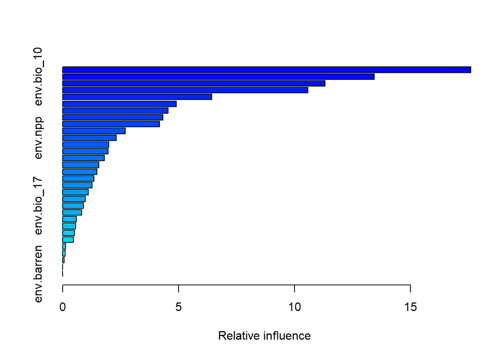

```
                              var    rel.inf
env.nontree           env.nontree 17.5928871
env.bio_10             env.bio_10 13.4379629
env.bio_13             env.bio_13 11.3103461
env.urban               env.urban 10.5688152
env.bio_5               env.bio_5  6.4292307
env.grass               env.grass  4.9087640
env.bio_7               env.bio_7  4.5415318
env.bio_8               env.bio_8  4.3201342
env.bio_9               env.bio_9  4.1736495
env.tree                 env.tree  2.6962604
env.npp                   env.npp  2.3169705
env.bio_19             env.bio_19  1.9970997
env.bio_14             env.bio_14  1.9688255
env.bio_16             env.bio_16  1.8024975
env.elev                 env.elev  1.5543143
env.bio_15             env.bio_15  1.4762665
env.savanna           env.savanna  1.3464401
env.bio_12             env.bio_12  1.2741631
env.bio_4               env.bio_4  1.1078061
env.bio_2               env.bio_2  0.9875704
env.bio_17             env.bio_17  0.9012152
env.bio_3               env.bio_3  0.8142793
env.nonveg             env.nonveg  0.5975114
env.bio_11             env.bio_11  0.5656003
env.bio_18             env.bio_18  0.5225713
env.woodysavanna env.woodysavanna  0.4742354
env.wetland           env.wetland  0.1236958
env.bio_6               env.bio_6  0.1162681
env.water               env.water  0.0730878
env.bio_1               env.bio_1  0.0000000
env.barren             env.barren  0.0000000
```

```r
summary(brt)
```

```r
variables_brt <- brt$contributions[1:6,] %>% pull(var)
#exploration of shape of relationships
#gbm.plot(brt, n.plots = 12, plot.layout=c(6, 2))
```

### Random forest

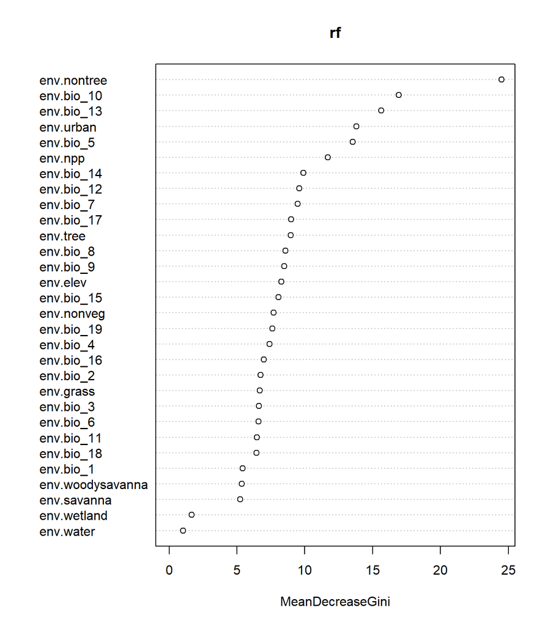

```r
presabs.rf <- PA %>%
  dplyr::select(-c(1,2,3,5)) %>%
  mutate(presabs = as.factor(presabs))

rf <- randomForest(presabs ~ .,
                   data=presabs.rf,
                   importance=T,
                   nperm=2, # two permutations per tree to estimate importance
                   na.action=na.omit,
                   mtry= 1/3*ncol(presabs.rf)-1)

varImpPlot(rf, type=2)
```

```r
variables_rf <- rf$importance %>% as_tibble(rownames = 'var') %>% arrange(desc(MeanDecreaseGini)) %>% head(n=6) %>% pull(var)
```

### Ranger

```r
presabs.ranger <- PA %>%
  dplyr::select(-c(1,2,3,5)) %>%
  filter(!if_any(everything(), is.na)) %>%
  mutate(presabs = as.factor(presabs))

## Learn the model:
ranger <- ranger(presabs ~ .,
                 data = presabs.ranger,
                 num.trees = 150,
                 mtry = 1/3*ncol(presabs.ranger)-1,
                 min.node.size = 5,
                 max.depth = NULL,
                 write.forest = TRUE,
                 importance = "impurity")


# Get the variable importance
importance(ranger)
```

```
       env.bio_1        env.bio_2        env.bio_3        env.bio_4
       4.8710126        5.7534748        6.2222304        6.8403644
       env.bio_5        env.bio_6        env.bio_7        env.bio_8
      10.8069284        6.2467870        9.3548681        8.9145375
       env.bio_9       env.bio_10       env.bio_11       env.bio_12
       7.4783494       17.1915980        6.0545874        8.8358500
      env.bio_13       env.bio_14       env.bio_15       env.bio_16
      15.4474758       11.3579645        7.2062521        6.0903619
      env.bio_17       env.bio_18       env.bio_19         env.elev
       7.6264652        7.2550260        7.3659486        8.2135374
       env.urban       env.barren        env.water      env.savanna
      11.9348489        0.1475352        1.0732435        5.1637631
env.woodysavanna      env.wetland        env.grass          env.npp
       4.6569940        1.8065060        5.9712772       13.1924531
        env.tree      env.nontree       env.nonveg
       8.0459004       23.4488548        7.0019669
```

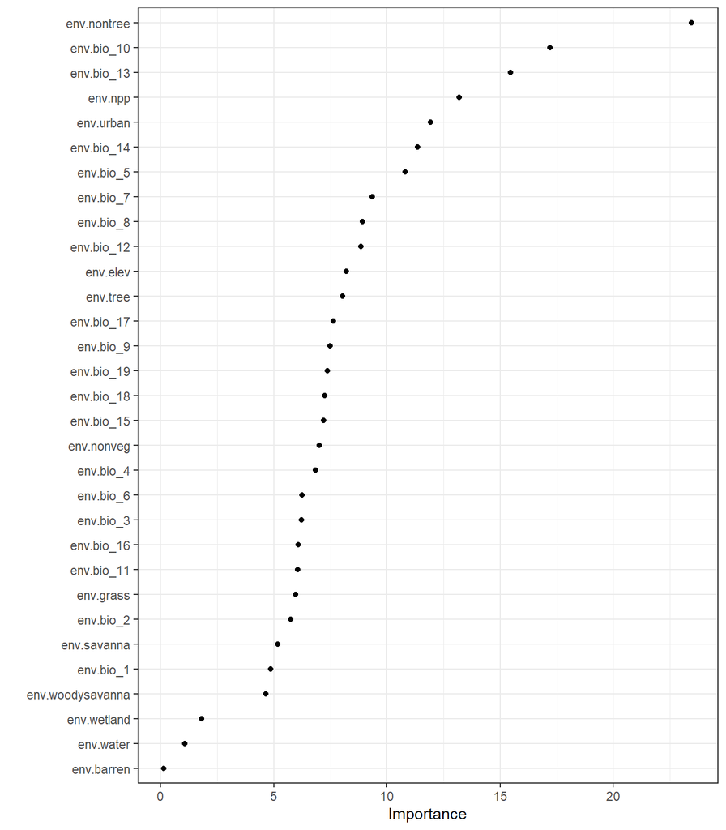

```r
importance(ranger) %>%
  as.data.frame(row.names = names(.)) %>%
  setNames(c("Importance")) %>%
  rownames_to_column("covariate") %>%
  # mutate(covariate = case_when(
  #   covariate == "env.bio_1" ~ "Annual Mean Temperature",
  # )) %>%
  ggplot(aes(x = Importance, y = reorder(covariate, Importance))) +
  ylab('')+
  geom_point() + theme_bw()
```

```r
variables_ranger <- importance(ranger) %>% as_tibble(rownames = 'var') %>% arrange(desc(value)) %>% head(n=6) %>% pull(var)
```

## Correlation

Correlation between the six more important variables detected.

- Boosted regression tree: env.nontree, env.bio_10, env.bio_13, env.urban, env.bio_5, env.grass
- Random forest: env.nontree, env.bio_10, env.bio_13, env.urban, env.bio_5, env.npp
- Ranger: env.nontree, env.bio_10, env.bio_13, env.npp, env.urban, env.bio_14

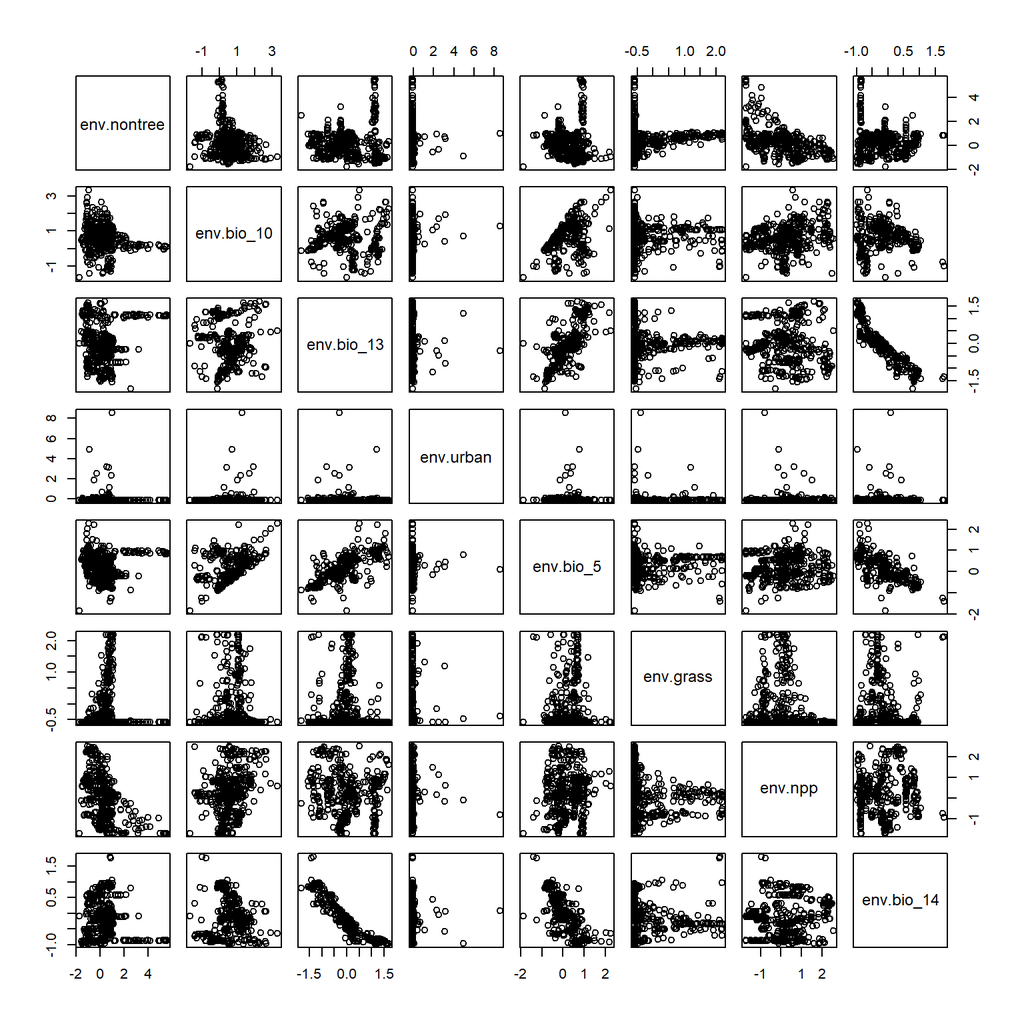

```r
selectedVariables <- unique(c(variables_brt, variables_rf, variables_ranger))

PA %>%
  filter(!if_any(everything(), is.na)) %>%
  dplyr::select(selectedVariables) %>%
  pairs()
```

```r
PA %>%
  filter(!if_any(everything(), is.na)) %>%
  dplyr::select(selectedVariables)  %>%
  cor() %>% kable()
```

|  | env.nontree | env.bio_10 | env.bio_13 | env.urban | env.bio_5 | env.grass | env.npp | env.bio_14 |
| --- | --- | --- | --- | --- | --- | --- | --- | --- |
| env.nontree | 1.0000000 | -0.1895589 | 0.1473409 | -0.0759533 | 0.0111147 | 0.2060164 | -0.5282644 | -0.0869051 |
| env.bio_10 | -0.1895589 | 1.0000000 | -0.0937538 | 0.2617832 | 0.3501940 | 0.0994479 | 0.2626821 | 0.1139535 |
| env.bio_13 | 0.1473409 | -0.0937538 | 1.0000000 | -0.1099554 | 0.6839703 | -0.0084892 | -0.1492964 | -0.9127157 |
| env.urban | -0.0759533 | 0.2617832 | -0.1099554 | 1.0000000 | 0.0445628 | -0.0789070 | 0.1355983 | 0.0473841 |
| env.bio_5 | 0.0111147 | 0.3501940 | 0.6839703 | 0.0445628 | 1.0000000 | 0.1192867 | 0.0732885 | -0.6703316 |
| env.grass | 0.2060164 | 0.0994479 | -0.0084892 | -0.0789070 | 0.1192867 | 1.0000000 | -0.1315989 | -0.0230030 |
| env.npp | -0.5282644 | 0.2626821 | -0.1492964 | 0.1355983 | 0.0732885 | -0.1315989 | 1.0000000 | 0.1162072 |
| env.bio_14 | -0.0869051 | 0.1139535 | -0.9127157 | 0.0473841 | -0.6703316 | -0.0230030 | 0.1162072 | 1.0000000 |

```r
tmpFiles(remove=T)
```